# Car Recommender

Millenial M’s

# Introduction

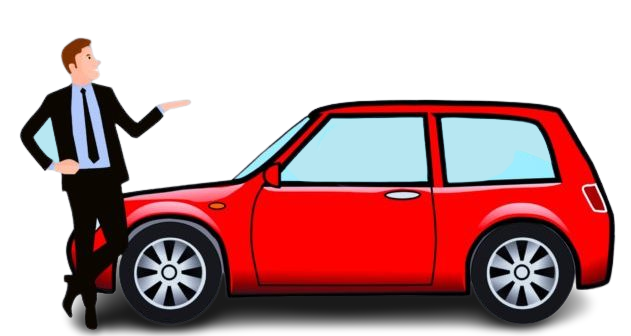

How did we come to Car Recommender Project

Problem statement

The increasing demand of cars of local brands each year, with little to no source and app to look for the in-depth details inside the domain has quite made us felt intrigued in making our steps to producing this archive-recommender from websites with the aim to make it easier for users to look for their desired vehicle.

What is the price range of the local car brands?

What is the car model with the highest price value in Malaysia?

Which year has most car model manufactured?

# Solution

We plan to produce an all local brand archive that gathers the details and informations of the models available domestically.

Objective

To identify the models available in Malaysia.

To show the graph illustration of car models in Malaysia.

To display the price of each car models in Malaysia.

# Features Available

Features that we have acquired from the dataset

-Car models according to their respective brands.

-Car models with their price and capacity.

-Car models on their year manufactured.

The dataset we used in this project is available at: https://docs.google.com/spreadsheets/d/1cY48QR95lGdRv0SRQr6kOh7d5wCAhFXShcFK_BpN0ug/edit#gid=0

# Screenshot of RShiny Application

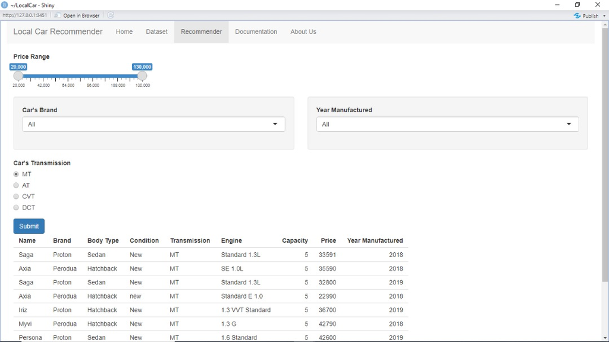